```python
from IPython.display import Image
```

# Linear Discriminant Analysis (LDA) - Theory

## LDA Overview

LDA uses Bayes' law to classify points, with the following assumptions:

- The data is normally distributed
- Features are statisticaly independent
- All covariance matrices are equal

The result of the LDA is a split of data into different classes.

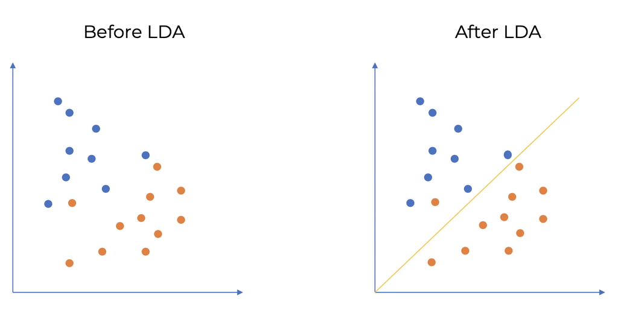

```python
Image("img/lda_before_after.png")
```

**Bayes' Law** states:

$P(A|B) = \frac{P(B|A)P(A)}{P(B)}$

This describes the probability of an event based on prior knowledge of conditions related to the event.

Within, LDA, suppose we have outcome $Y\in\{1,...,K\}$. E.x. $Y\in\{Yes, No, Maybe\}$.

We want to know the probability of an outcome $k$ given the points (or covariates) $x$:

- $p_k(x)=P(Y=k|X=x)$

We then classify $p_k(x)$ based off of whichever has the highest probability.

For example, suppose we have a dataset that has the following data fields:

- $Y\in\{Candidate\:A, Candidate\:B, Candidate\:C\}$
- $Party\in\{Democrat,\:Republican,\:Independent\}$
- $State\in\{New\:York,\:Texas,\:Vermont\}$

And we calculate the following conditional probabilities for one outcome:

- $P(Y=Candidate\:A|X=\{Democrat,\:New\:York\} = 0.1)$
- $P(Y=Candidate\:B|X=\{Democrat,\:New\:York\} = 0.6)$
- $P(Y=Candidate\:C|X=\{Democrat,\:New\:York\} = 0.3)$

Then we would say that given $X=\{Democrat, New York\}$, the classification is $Candidate B$ since it has the greatest probability.

## LDA - Generalized

$p_k(x)=P(Y=k|X=x)=\frac{\pi_kf_k(x)}{\sum_{l=1}^{K}\pi_lf_l(x)}$

where:

- $\pi_k = P(Y=k)$
- The conditional distribution $X|Y = k$ is $f_k(x)$

This can be seen as an expression of Bayes' Law with more than two classes. What we are saying is:

- "The probability of event $Y$ being classified as class $k$ given all prior knowledge of conditions related to the event $Y$ is $p_k(x)$"

## Issues with LDA

- Does not work well if classes are not balanced
  - I.e. The number of objects in different classes are very different
- Not applicable for non-linear problems
  - I.e. The data cannot be split up by linear lines
- Sensitive to overfitting

## More Resources

[Intro to Bayesian Statistics](https://www.analyticsvidhya.com/blog/2016/06/bayesian-statistics-beginners-simple-english/)

[LDA for ML](https://machinelearningmastery.com/linear-discriminant-analysis-for-machine-learning/)